# Tarea 07: Ejercicios Unidad 03-B splines

### CONJUNTO DE EJERCICIOS

- Mateo Molina Moises Estrella

**Link Repositorio:** https://github.com/R3LM15/MetodosNumericos_MateoMolina

### 1. Dados los puntos (0,1), (1,5), (2,3), determine el spline cúbico.

$$ S_o(X) = a_0 + B_0(x-x_0) + c_0(x-x_0)^2 + D_0(x-x_0)^3 $$

-> $ S_0(X) = a_0 + b_0(x-x_0) + c_0(x-x_0)^2 + d_0(x-x_0)^3 $

$ S_0(X) = a_0 + b_0(x) + c_0(x)^2 + d_0(x)^3 $

-> $ S_1(X) = a_1 + b_1(x-x_1) + c_1(x-x_1)^2 + d_1(x-x_1)^3 $

$ S_1(X) = a_1 + b_1(x-1) + c_1(x-1)^2 + d_1(x-1)^3 $

Ecuaciones

1. $S_0(X_0) = y_0 $

$ a_0 + b_0(x_0) + c_0(x_0)^2 + d_0(x_0)^3 = 1 $

$ a_0 = 1$

2. $S_0(X_1) = y_1 $

$ a_0 + b_0(x_1) + c_0(x_1)^2 + d_0(x_1)^3 = 5$

$ 1 + b_0 + c_0 + d_0 = 5$

$ b_0 + c_0 + d_0 = 4 $

3. $ S_1(x_1) = y_1 $

$ a_1 + b_1(x_1-x_1) + c_1(x_1-x_1)^2 + d_1(x_1-x_1)^3 = 5 $

$ a_1 = 5 $

4. $ S_1(x_2) = y_2 $

$ a_1 + b_1(x_2-x_1) + c_1(x_2-x_1)^2 + d_1(x_2-x_1)^3 = 3 $

$ 5 + b_1(2-1) + c_1(2-1)^2 + d_1(2-1)^3 = 3$

$ 5 + b_1 + c_1 + d_1 = 3$

$ b_1 + c_1 + d_1 = -2$

5. $𝑆_0'(x_1) = 𝑆_1'(x_1)$

$ b_0(x_1) + c_0(x_1)^2 + d_0(x_1)^3 = a_1 + b_1(x_1-1) + c_1(x_1-1)^2 + d_1(x_1-1)^3$

$ b_0 + 2c_0(x_1) + 3d_0(x_1)^2 = b_1 + 2c_1(x_1-1) + 3d_1(x_1-1)^2$

$ b_0 + 2c_0 + 3d_0 = b_1$

6. $𝑆_0''(x_1) = 𝑆_1''(x_1)$

$ 2c_0 + 6d_0 x =2c_1 +6d_1(x-1)$

$ 2c_0 + 6d_0 (x_1) =2c_1 +6d_1(x_1-1)$

$ 2c_0 + 6d_0 =2c_1$

$ c_0 + 3d_0 =c_1$

7. $ 𝑆_0''(x_0) = 0 $

$c_0 +3d_0(x_0)=0 $

$c_0 = 0 $

8. $ 𝑆_1''(x_2) = 0 $

$c_1 +3d_1(x_2-1)=0 $

$c_1+3d_1 = 0 $

Sistemas de Ecuaciones

- $b_0 +d_0=4 $
- $b_1 +c_1+d_1=-2 $
- $ b_0 + 3d_0 = b_1$
- $ 3d_0 =c_1$
- $c_1+3d_1 = 0 $

Spines

### 2. Dados los puntos (−1,1), (1,3), determine el spline cúbico sabiendo que 𝑓′(𝑥0) =1, 𝑓′(𝑥𝑛) = 2.

$$ S_0(X) = a_0 + B_0(x+1) + c_0(x+1)^2 + D_0(x+1)^3 $$

Ecuaciones

1. $S(X_0) = y_0 $

$a_0 + B_0(X_0+1) + c_0(X_0+1)^2 + D_0(X_0+1)^3 = y_0 $

$a_0 = 1 $

2. $S(X_1) = y_1 $

$a_0 + B_0(X_1+1) + c_0(X_1+1)^2 + D_0(X_1+1)^3 = y_1 $

$b_0 + 2c_0 + 4d_0 = 1 $

3. $S'(X_0) = 1 $

$b_0 +2c_0(x_0+1)+3d_0(x_0+1)^2 =1$

$b_0 =1$

4. $S'(X_1) = 2 $

$b_0 +2c_0(x_1+1)+3d_0(x_1+1)^2 =2$

$4c_0+12d_0 =1$

Sistema de Ecuaciones

- $c=-2d$
- $4c+12d=1$

Coeficientes finales

- a =1
- b=1
- c = - 1/2
- d = 1/4

El spline cúbico es:

$$ S(x) = 1 + 1(x+1) - \frac{1}{2}(x+1)^2 + \frac{1}{4}(x+1)^3 $$

### 3. Diríjase al pseudocódigo del spline cúbico con frontera natural provisto en clase, en base a ese pseudocódigo complete la siguiente función:

```python
import sympy as sym
from IPython.display import display


# ###################################################################
def cubic_spline(xs: list[float], ys: list[float]) -> list[sym.Symbol]:

    points = sorted(zip(xs, ys), key=lambda x: x[0])  # sort points by x

    xs = [x for x, _ in points]
    ys = [y for _, y in points]

    n = len(points) - 1  # number of splines

    h = [xs[i + 1] - xs[i] for i in range(n)]  # distances between  contiguous xs

    alpha = [0] * n
    for i in range(1, n):
        alpha[i] = 3 / h[i] * (ys[i + 1] - ys[i]) - 3 / h[i - 1] * (ys[i] - ys[i - 1])

    l = [1]
    u = [0]
    z = [0]

    for i in range(1, n):
        l += [2 * (xs[i + 1] - xs[i - 1]) - h[i - 1] * u[i - 1]]
        u += [h[i] / l[i]]
        z += [(alpha[i] - h[i - 1] * z[i - 1]) / l[i]]

    l.append(1)
    z.append(0)
    c = [0] * (n + 1)

    x = sym.Symbol("x")
    splines = []
    for j in range(n - 1, -1, -1):
        c[j] = z[j] - u[j] * c[j + 1]
        b = (ys[j + 1] - ys[j]) / h[j] - h[j] * (c[j + 1] + 2 * c[j]) / 3
        d = (c[j + 1] - c[j]) / (3 * h[j])
        a = ys[j]
        print(j, a, b, c[j], d)
        S = a + b * (x - xs[j]) + c[j] * (x - xs[j]) ** 2 + d * (x - xs[j]) ** 3

        splines.append(S)
    splines.reverse()
    return splines
```

### 4. Usando la función anterior, encuentre el spline cúbico para:

```python
xs = [1, 2, 3]
ys = [2, 3, 5]

splines = cubic_spline(xs=xs, ys=ys)
_ = [display(s) for s in splines]
print("______")
_ = [display(s.expand()) for s in splines]
```

```
1 3 1.5 0.75 -0.25
0 2 0.75 0.0 0.25
```

$\displaystyle 0.75 x + 0.25 \left(x - 1\right)^{3} + 1.25$

$\displaystyle 1.5 x - 0.25 \left(x - 2\right)^{3} + 0.75 \left(x - 2\right)^{2}$

```
______
```

$\displaystyle 0.25 x^{3} - 0.75 x^{2} + 1.5 x + 1.0$

$\displaystyle - 0.25 x^{3} + 2.25 x^{2} - 4.5 x + 5.0$

### 5. Usando la función anterior, encuentre el spline cúbico para:

```python
xs = [0, 1, 2, 3]
ys = [-1 ,1, 5, 2]

splines = cubic_spline(xs=xs, ys=ys)
_ = [display(s) for s in splines]
print("______")
_ = [display(s.expand()) for s in splines]
```

```
2 5 1.0 -6.0 2.0
1 1 4.0 3.0 -3.0
0 -1 1.0 0.0 1.0
```

$\displaystyle 1.0 x^{3} + 1.0 x - 1$

$\displaystyle 4.0 x - 3.0 \left(x - 1\right)^{3} + 3.0 \left(x - 1\right)^{2} - 3.0$

$\displaystyle 1.0 x + 2.0 \left(x - 2\right)^{3} - 6.0 \left(x - 2\right)^{2} + 3.0$

```
______
```

$\displaystyle 1.0 x^{3} + 1.0 x - 1$

$\displaystyle - 3.0 x^{3} + 12.0 x^{2} - 11.0 x + 3.0$

$\displaystyle 2.0 x^{3} - 18.0 x^{2} + 49.0 x - 37.0$

### 6. Use la función cubic_spline_clamped, provista en el enlace de Github, para graficar los datos de la siguiente tabla.

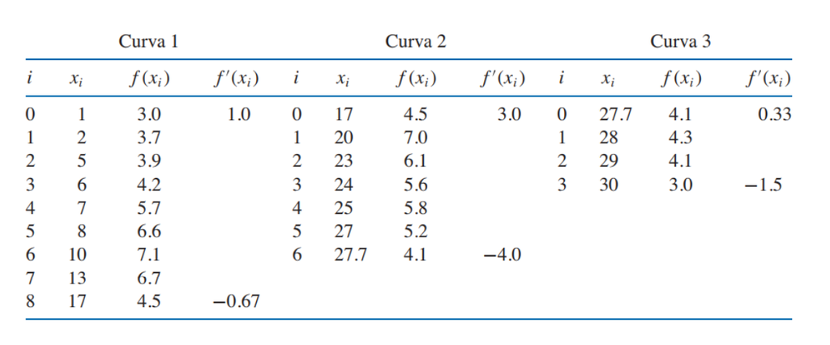

```python
import sympy as sym
import numpy as np
import matplotlib.pyplot as plt


def cubic_spline_clamped(xs, ys, B0, B1):
    """
    Calcula y grafica splines cúbicos con condiciones de derivada en los extremos (clamped).
    """

    # Ordenar puntos por x
    points = sorted(zip(xs, ys), key=lambda x: x[0])
    xs = [x for x, _ in points]
    ys = [y for _, y in points]
    n = len(xs) - 1
    h = [xs[i + 1] - xs[i] for i in range(n)]

    # Paso 1: calcular alpha
    alpha = [0] * (n + 1)
    alpha[0] = 3 / h[0] * (ys[1] - ys[0]) - 3 * B0
    alpha[-1] = 3 * B1 - 3 / h[-1] * (ys[-1] - ys[-2])
    for i in range(1, n):
        alpha[i] = 3 / h[i] * (ys[i + 1] - ys[i]) - 3 / h[i - 1] * (ys[i] - ys[i - 1])

    # Paso 2: resolver sistema tridiagonal
    l = [2 * h[0]]
    u = [0.5]
    z = [alpha[0] / l[0]]
    for i in range(1, n):
        l.append(2 * (xs[i + 1] - xs[i - 1]) - h[i - 1] * u[i - 1])
        u.append(h[i] / l[i])
        z.append((alpha[i] - h[i - 1] * z[i - 1]) / l[i])
    l.append(h[-1] * (2 - u[-1]))
    z.append((alpha[-1] - h[-1] * z[-1]) / l[-1])

    # Paso 3: construir coeficientes
    c = [0] * (n + 1)
    c[-1] = z[-1]
    for j in range(n - 1, -1, -1):
        c[j] = z[j] - u[j] * c[j + 1]

    x_sym = sym.Symbol("x")
    splines = []
    for j in range(n):
        b = (ys[j + 1] - ys[j]) / h[j] - h[j] * (c[j + 1] + 2 * c[j]) / 3
        d = (c[j + 1] - c[j]) / (3 * h[j])
        a = ys[j]
        S = a + b * (x_sym - xs[j]) + c[j] * (x_sym - xs[j]) ** 2 + d * (x_sym - xs[j]) ** 3
        splines.append((S, (xs[j], xs[j + 1])))

    # Gráfica
    plt.figure(figsize=(10, 5))
    for S, (xi, xf) in splines:
        f_lambd = sym.lambdify(x_sym, S, modules=["numpy"])
        x_vals = np.linspace(xi, xf, 100)
        y_vals = f_lambd(x_vals)
        plt.plot(x_vals, y_vals, label=f"${sym.simplify(S)}$")

    # Graficar puntos originales
    plt.plot(xs, ys, "o", color="black", label="Datos")

    plt.title("Spline Cúbico con Condiciones de Borde (Clamped)")
    plt.xlabel("x")
    plt.ylabel("S(x)")
    plt.grid(True)
    plt.legend(loc="best")
    plt.tight_layout()
    plt.show()

    return [S for S, _ in splines]  # devuelve solo las expresiones
```

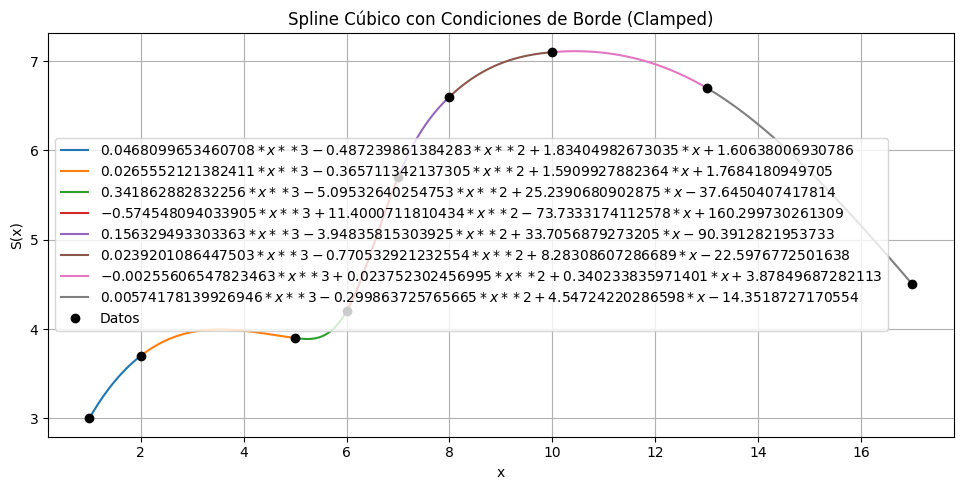

```python
splines = cubic_spline_clamped(
    xs=[1, 2, 5, 6, 7, 8, 10, 13, 17],
    ys=[3.0, 3.7, 3.9, 4.2, 5.7, 6.6, 7.1, 6.7, 4.5],
    B0=1,
    B1=-0.67,
)
```

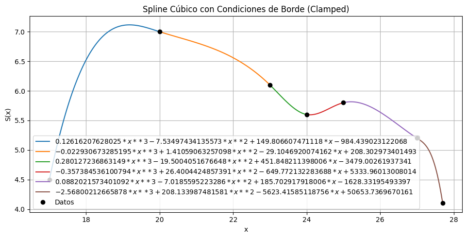

```python
splines = cubic_spline_clamped(
    xs=[17, 20, 23, 24, 25, 27, 27.7],
    ys=[4.5, 7.0, 6.1, 5.6, 5.8, 5.2, 4.1],
    B0=3.0,
    B1=-4.0,
)
```

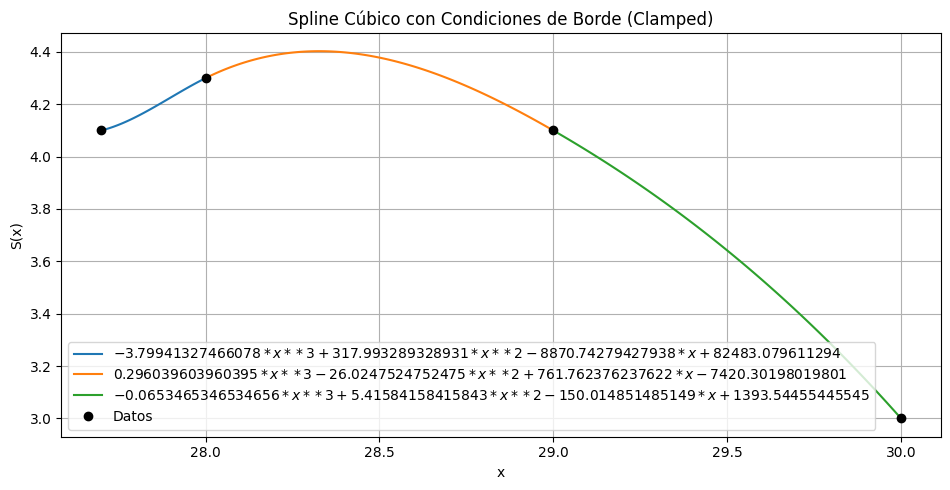

```python
splines = cubic_spline_clamped(
    xs=[27.7, 28, 29, 30],
    ys=[4.1, 4.3, 4.1, 3.0],
    B0=0.33,
    B1=-1.5,
)
```